Reproducible Research: Peer Assessment 1

### 1. Loading and preprocessing the data

```r
filename <- "activity.csv"
file_in <- read.csv(filename,header=TRUE, sep="," )
```

### 2. What is mean total number of steps taken per day?

#### 2.1 Print Total Number of Steps Taken Per Day

```
##           Day Steps_Per_day
## 1  2012-10-02           126
## 2  2012-10-03         11352
## 3  2012-10-04         12116
## 4  2012-10-05         13294
## 5  2012-10-06         15420
## 6  2012-10-07         11015
## 7  2012-10-09         12811
## 8  2012-10-10          9900
## 9  2012-10-11         10304
## 10 2012-10-12         17382
## 11 2012-10-13         12426
## 12 2012-10-14         15098
## 13 2012-10-15         10139
## 14 2012-10-16         15084
```

[output cut: 39 more lines]

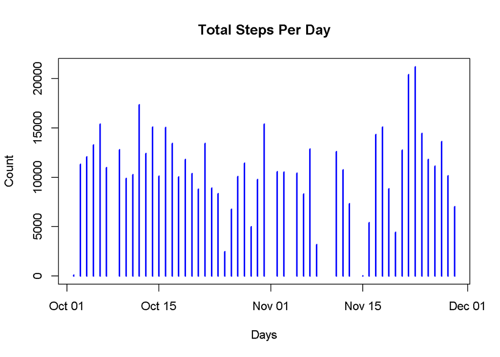

#### 2.3 Mean and median of the total number of steps taken per day

```
## [1] "Mean of the total number of steps taken per day : 10766.1886792453"
```

```
## [1] "Median of the total number of steps taken per day : 10765"
```

### 3. What is the average daily activity pattern?

#### 3.1 time Series plot of 5-minute interval and the average number of steps taken, averaged across all days

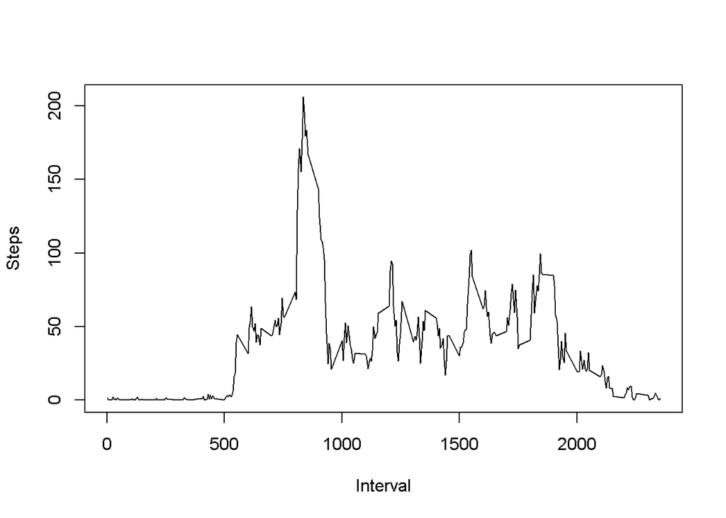

#### 3.2 identify which 5-minute interval, on average across all the days in the dataset, contains the maximum number of steps

```
## [1] "5-minute interval that contains the maximum number of steps : 835"
## [2] "5-minute interval that contains the maximum number of steps : 206.169811320755"
```

### 4. Inputing missing values

#### 4.1 Calculate and report the total number of missing values in the dataset (i.e. the total number of rows with NAs)

```
## [1] "Number of a 5-min intervals missing from the data-set = 2304"
```

#### 4.2 Devise a strategy for filling in all of the missing values in the dataset. The strategy does not need to be sophisticated.

- My strategy is to replace NA with daily mean
- Create a new dataset that is equal to the original dataset but with the missing data filled in
- New Data Set :

```
## 'data.frame':    17568 obs. of  3 variables:
##  $ steps   : num  37.4 37.4 37.4 37.4 37.4 ...
##  $ date    : Date, format: "2012-10-01" "2012-10-01" ...
##  $ interval: int  0 5 10 15 20 25 30 35 40 45 ...
```

```
## [1] "Missing values from New data-set = 0"
```

#### 4.3 Total number of steps taken each day with new set

```
##           Day Steps_Per_day
## 1  2012-10-01      10766.19
## 2  2012-10-02        126.00
## 3  2012-10-03      11352.00
## 4  2012-10-04      12116.00
## 5  2012-10-05      13294.00
## 6  2012-10-06      15420.00
## 7  2012-10-07      11015.00
## 8  2012-10-08      10766.19
## 9  2012-10-09      12811.00
## 10 2012-10-10       9900.00
## 11 2012-10-11      10304.00
## 12 2012-10-12      17382.00
## 13 2012-10-13      12426.00
## 14 2012-10-14      15098.00
```

[output cut: 47 more lines]

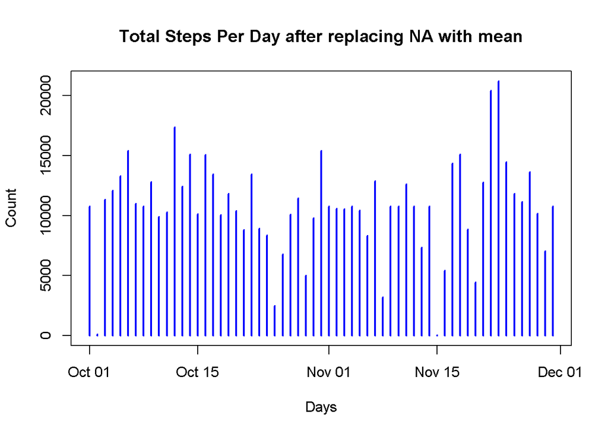

#### 4.4 Mean and median of the total number of steps taken per day

```
## [1] "Mean of the total number of steps taken per day : 10766.1886792453"
```

```
## [1] "Median of the total number of steps taken per day : 10766.1886792453"
```

#### 4.4 Difference

```
## [1] "The difference in means is 0"
```

```
## [1] "The difference in median is 1.19000000000051"
```

### 5. Are there differences in activity patterns between weekdays and weekends?

#### 5.1 Create new factor variable in the dataset with two levels - “weekday” and “weekend” indicating whether a given date is a weekday or weekend day

```
## [1] " New variable in dataset :"
```

```
## 'data.frame':    17568 obs. of  5 variables:
##  $ steps   : num  37.4 37.4 37.4 37.4 37.4 ...
##  $ date    : Date, format: "2012-10-01" "2012-10-01" ...
##  $ interval: int  0 5 10 15 20 25 30 35 40 45 ...
##  $ dow     : chr  "Monday" "Monday" "Monday" "Monday" ...
##  $ iswknd  : Factor w/ 2 levels "No","Yes": 1 1 1 1 1 1 1 1 1 1 ...
```

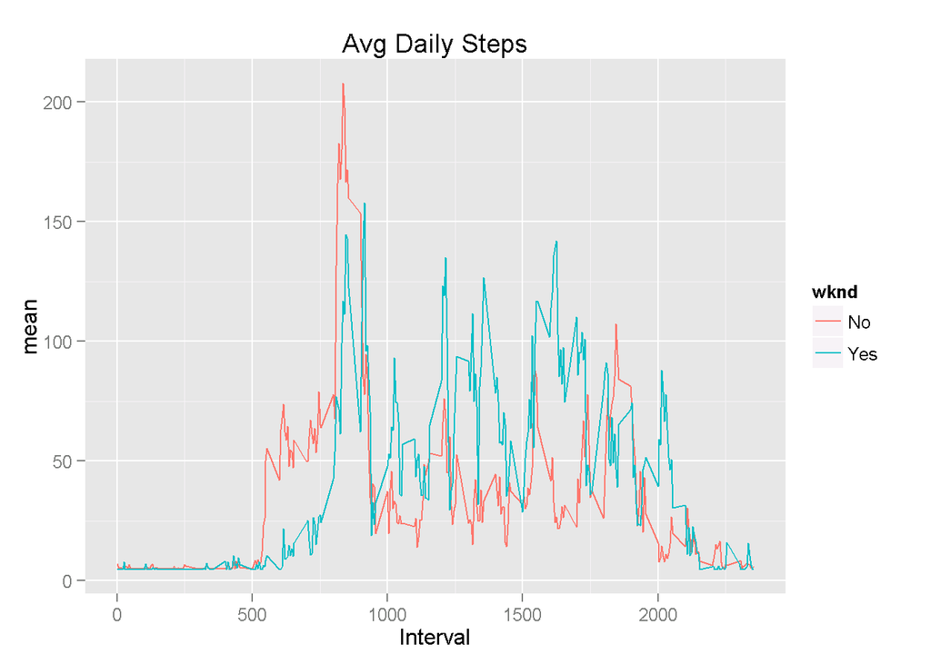